# Prinstats homework 1

Here is the link to get the code from github https://github.com/chamyields/mastats/tree/main/pinstats_2020

## Questions

Consider the paper of David Spiegelhalter (available on Ufora). In this paper the author examines the age-specific risk of dying (with or from) Covid-19 in the UK. Table 2 in the paper, gives for several age categories the numbers of reported Covid-19 deaths, numbers of non-covid related deaths, population sizes, among other numbers.

## 1. Question

Assign to each age interval a numerical value given by the midpoint (e.g. for 0-4, the midpoint is (0+4)/2 =2) and let $p_i$ denote the corresponding population size in the UK. Assume that the number of non-covid deaths $(Y^N )$ within an age class with midpoint $a_i$ $(i = 1,\ldots , 11)$ can be described by a Poisson distribution with mean given by

$$\text{E}(Y^N|\text{age}=a_i) = p_i\exp(\beta_0^N+\beta_1^Na_i)$$

(the superscript refers to non-covid). Also for the covid-related deaths $(Y^C)$ we assume a Poisson distribution with

$$\text{E}(Y^C|\text{age}=a_i) = p_i\exp(\beta_0^C+\gamma\beta_1^Na_i)$$

*How do you interpret the $\gamma$ parameter?*

### Solution

Besides the first and the last age intervals, the difference between the mid point from one age group to the other is 10 years.

## 2. Question

Given the models from the previous question, and assuming that all num- bers of deaths (both covid and non-covid) are independently distributed. Construct the log-likelihood function and make a graph of the log-likelihood as a function of the $\gamma$ parameter. You may use the following estimates for the other parameters:

$$\beta_0^N = −12.06 ~~ \beta_0^C = −14.15 ~~ \beta_1^N = 0.09836$$

### Solution

We have been told that $Y^N$ and $Y^C$ follow a Poisson distribution, recall that if a random variable $K$ follows a Poission distribution, it has the follow mass function

$$P_\lambda(K=k) = f(k|\lambda) = \frac{\lambda^{k}e^{-\lambda}}{k!}$$
Let’s say we have observed $n$ values from $n$ random variables $K_1,\ldots,K_n$ that are:

- all identically distributed (i.e. they all follow a Poisson distribution with parameter $\lambda_i$, well not exactly identical since their mean $\lambda$s are different)
- independent, i.e, $P(K_1,\ldots,K_n) = \prod_i P(K_i)$

The likelihood is then defined as a function of $\mathbf \Lambda = (\lambda_1,\ldots,\lambda_n)$ given the data, i.e.,
$$L(\mathbf \Lambda|K_1=k_1,\ldots,K_n=k_n) = \prod_i P_{\lambda_i}(K_i=k_i) = \prod_if(k_i|\lambda_i) = \prod_i\frac{\lambda_i^{k_i}e^{-\lambda_i}}{k_i!}$$
The log likelihood which is simpler transformation to work with is given by
$$l(\Lambda|K_1=k_1,\ldots,K_n=k_n) = \log \prod_i P_{\lambda_i}(K_i=k_i) = \sum_i\log\frac{\lambda_i^{k_i}e^{-\lambda_i}}{k_i!}$$

$$l(\Lambda|K_1=k_1,\ldots,K_n=k_n) = \sum_i \big(k_i \log\lambda_i - \lambda_i - \log k_i!\big)$$

$$l(\Lambda|K_1=k_1,\ldots,K_n=k_n) = \sum_i k_i \log\lambda_i - \sum_i \lambda_i - \sum_i \log k_i!$$

For the problem at hand we have:

- $\lambda_i^N = \text{E}(Y^N|\text{age}=a_i)$ for non-covid 19 deads
- $\lambda_i^C (\gamma) = \text{E}(Y^C|\text{age}=a_i)$ for covid 19 deads
- our parameter of interest is $\gamma$.
- samples size $n_N=11$ for the covid-19 deads
- samples size $n_C=11$ for the non-covid-19 deads

$$l(\gamma|Y^C_1=Y^C_1,\ldots,Y^C_n=Y^C_n,Y^N_1=y^N_1,\ldots,Y^N_n=y^N_n) = \log \Pi_if(Y^C|\lambda_i^C(\gamma))f(y_i^N|\lambda_i^N)$$
$$l(\gamma|Y^C_1=Y^C_1,\ldots,Y^C_n=Y^C_n,Y^N_1=y^N_1,\ldots,Y^N_n=y^N_n) = \sum_{i=1}^{11}\log f(Y^C|\lambda_i^C(\gamma))+\sum_{i=1}^{11}\log f(y_i^N|\lambda_i^N)$$
$$l(\gamma|Y^C_1=Y^C_1,\ldots,Y^C_n=Y^C_n,Y^N_1=y^N_1,\ldots,Y^N_n=y^N_n) = \sum_{i=1}^{11}\big(Y^C\log \lambda_i^C(\gamma) + y_i^N\log \lambda_i^N\big) -\sum_{i=1}^{11}\big(\lambda_i^C(\gamma)+\lambda_i^N\big)-\sum_{i=1}^{11}\log (Y^Cy_i^N)$$
We can simply write our log likelihood function as

$$l(\gamma) = \sum_{i=1}^{11}\big(Y^C\log \lambda_i^C(\gamma) + y_i^N\log \lambda_i^N\big) -\sum_{i=1}^{11}\big(\lambda_i^C(\gamma)+\lambda_i^N\big)-\sum_{i=1}^{11}\log (Y^CY^N)$$
So we have our log likelihood function lets code it in `R`.

```r
library(dplyr,
        verbose=FALSE)
library(tidyverse,
        verbose = FALSE)
age_mid_point = function(x,y){
  (x+y)/2
}

beta_0_C_hat = -14.15
beta_1_N_hat = 0.09836
beta_0_N_hat = -12.06

lb = c(0,5,15,25,35,45,55,65,75,85)
ub = c(4,14,24,34,44,54,64,74,84,89)

age = c(age_mid_point(lb,ub),90)

Y_C = c(3,3,33,128,369,1283,3476,7319,16043,10160,10790)

population = c(3535430,7159102,6988755,
               7998302,7460856,8142528,
               7019590,5906928,3476922,
               918437,528959)

Y_N = c(848,138,470,1141,2577,6577,13565,27184,47729,30703,30703)

data = data.frame(age,Y_N,Y_C,population)


beta_0_C = beta_0_C_hat
beta_0_N = beta_0_N_hat
beta_1_N = beta_1_N_hat


log_l = function(gamma_hat){

  lambda_N = data$population*exp(beta_0_N+beta_1_N*data$age)
  lambda_C = data$population*exp(beta_0_C+gamma_hat*beta_1_N*data$age)

  sum_1 = data$Y_C*log(lambda_C)+data$Y_N*log(lambda_N)
  sum_2 = lambda_C+lambda_N
  sum_3 = log(data$Y_C*data$Y_N)

  sum_all= sum(sum_1-sum_2-sum_3)
  return(-sum_all)
}
data
```

| age | Y_N | Y_C | population |
| --- | --- | --- | --- |
| 2.0 | 848 | 3 | 3535430 |
| 9.5 | 138 | 3 | 7159102 |
| 19.5 | 470 | 33 | 6988755 |
| 29.5 | 1141 | 128 | 7998302 |
| 39.5 | 2577 | 369 | 7460856 |
| 49.5 | 6577 | 1283 | 8142528 |
| 59.5 | 13565 | 3476 | 7019590 |
| 69.5 | 27184 | 7319 | 5906928 |
| 79.5 | 47729 | 16043 | 3476922 |
| 87.0 | 30703 | 10160 | 918437 |

[output cut: 1 more lines]

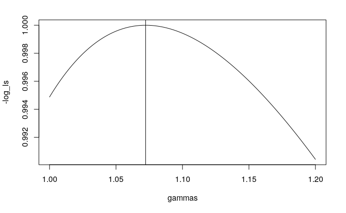

```r
log_ls = c()
gammas = seq(1,1.2,length.out = 1000)
for(gamma in gammas){
  log_ls  = c(log_l(gamma),log_ls)
}

log_ls = log_ls/max(abs(log_ls))

plot(x=gammas,y=-log_ls,type="l")
abline(v=gammas[-log_ls==max(-log_ls)])
```

```r
paste0('optimal gamma: ',round(gammas[-log_ls == max(-log_ls)],3))
```

```
[1] "optimal gamma: 1.072"
```

## 3.Question

Use the optim (or similar) function in R for finding the maxi- mum likelihood estimate of $\gamma$.

### Solution

Lets look for $\gamma$ with `optim`

```r
# initial value of gamma
par = 0

opt = optim(par=par,
      fn= log_l)
```

```
one-dimensional optimization by Nelder-Mead is unreliable:
use "Brent" or optimize() directly
```

```r
opt
```

```
$par
[1] 1.127734

$value
[1] -1888745

$counts
function gradient
      32       NA

$convergence
[1] 0

$message
NULL
```

Can you compare the results of the manual computation with that of `optim`. They seem to be different? Please check if there are any mistakes in my computations

```r
plot(x=gammas,y=-log_ls,type="l")
abline(v=gammas[-log_ls==max(-log_ls)],col='blue')
```

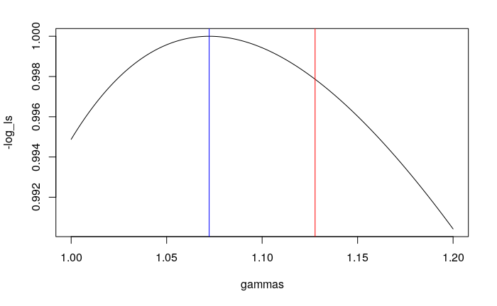

```r
abline(v=opt$par,col='red')
```

- Note that our `log_l` function returns the `negative` log likelihood instead because `optim` is a minimisation function.
- I checked the paper for the maximum likelihood estimator of $\gamma$, they also have $(1.128)$, the value from the `optim` function. So emm…. let’s check the `optimise` function ;)

```r
optimize(log_l,c(-2,2))
```

```
$minimum
[1] 1.127681

$objective
[1] -1888745
```

## 4. Question

with the information in Table 2 and with the models and their parameter estimates of the previous questions, estimate the following two probabilities:
$$\text{P} (\text{Age} = 19.5 | \text{ died of covid}) \text{ and } \text{P} (\text{Age} = 79.5 | \text{ died of covid})$$

### Solution

Bayes theorem: for two random variables $X$ and $Y$,
$$P(X|Y) = \frac{P(Y|X)P(X)}{P(Y)}$$

Hence

$$\text{P} (\text{Age} = 19.5 | \text{ died of covid}) = \frac{\text{P} ( \text{ died of covid} | \text{Age} = 19.5 ) \text{P} (\text{Age} = 19.5)}{\text{P}( \text{ died of covid})}$$

- further, use these values and plug into the formula above.

$$\text{P} ( \text{ died of covid} | \text{Age} = 19.5 ) = \frac{\text{E}(Y^C|\text{Age} = 19.5)}{\text{population size with mid point at age 19.5}}$$
$$\text{P} (\text{Age} = 19.5) = \frac{\text{Population size with mid point at 19.5}}{\text{Total population size across all age groups}}$$

$$\text{P} (\text{ died of covid}) = \frac{\text{Total number of people who died from covid across all age groups}}{\text{Total population size across all age groups}}$$

Fill the values and compute this probability, do the same for $\text{P} (\text{Age} = 79.5 | \text{ died of covid})$

## Question 5.

For this question you may assume that the numerical values for (the estimates) $\beta_0^C$, $\beta^N_0$ and $\beta_1^N$ that were given in question 2, are the true population parameter values.Set up a simulation study in which you simulate data (as in Table 2) for the covid and non-covid related deaths, and calculate the maximum likelihood estimate of $\gamma$ for each simulated dataset.

- Plot a histogram of the estimates of $\gamma$. How do you interpret this histogram?
- Assess whether the estimates agree with a normal distribution.

### Solution

```r
n=11
gamma_hat = 1.2

lambda_N = data$population*exp(beta_0_N+beta_1_N*data$age)
lambda_C = data$population*exp(beta_0_C+gamma_hat*beta_1_N*data$age)

max_lik_est = c()
num_simulations = 1000

for(k in 1:num_simulations){

  # set.seed(k)

  Y_C = rpois(n,lambda_C)
  Y_N = rpois(n,lambda_N)
  data = data.frame(age,Y_N,Y_C,population)

  par = 1

  opt = optimize(log_l,c(-1.5,1.5));

  max_lik_est[k] = opt$minimum
}
m<-mean(max_lik_est)
std<-sqrt(var(max_lik_est))

hist(max_lik_est,
     col = 'skyblue3',
     breaks = 20,
     prob=TRUE)
curve(dnorm(x, mean=m, sd=std),
      col="red",
      lwd=3,
      add=TRUE,
      yaxt="n")

print('')
```

[output not shown]

Assessing normality

```r
qqnorm(max_lik_est, pch = 1, frame = FALSE)
qqline(max_lik_est, col = "steelblue", lwd = 2)
```

[output not shown]

```r
### taking out max_lik that are greater 1.4
sub_max_lik = max_lik_est[max_lik_est<1.4]

m<-mean(sub_max_lik)
std<-sqrt(var(sub_max_lik))

hist(sub_max_lik,
     col= 'skyblue3',
     breaks = 20,
     prob=TRUE)

curve(dnorm(x, mean=m, sd=std),
      col="red", lwd=3, add=TRUE, yaxt="n")
abline(v=mean(sub_max_lik),col="pink",lwd=3)
abline(v=gamma_hat,col="green",lwd=3)
```

[output not shown]

```r
qqnorm(sub_max_lik, pch = 1, frame = FALSE)
qqline(sub_max_lik, col = "steelblue", lwd = 2)
```

[output not shown]

## Question 6

For this question you may again assume that the numerical values for $\beta_0^C$, $\beta^N_0$ and $\beta_1^N$ that were given in question 2, are the true population parameter values. We now consider the log-likelihood function of question 2 as a function of $\gamma$, say $l(\gamma)$. In likelihood theory there is a result that says that in large samples, the following approximately holds:

$$2(l(\hat \gamma) − l(\gamma)) \stackrel{d}{=}\chi_1^2$$

Upon using this result, construct a 95% confidence interval for the parameter $\gamma$ and report this interval for the data from Table 2 (i.e. for the fitted model from question 3). How do you interpret this result and what is your final conclusion of your data analysis?

### Solution

Note that $2(l(\hat \gamma) − l(\gamma)) \stackrel{d}{=}\chi_1^2$ gives rise to the well known likelihood-ratio (LR) test.

In the LR test of the null hypothesis
$$H_0:\gamma = \gamma_0$$
versus the two-sided alternative
$$H_1:\gamma \neq \gamma_0$$
we would reject $H_0$ at the $\alpha$-level if the LR statistic exceeds the $100(1-\alpha/2)$th or is below $\alpha/2$ percentile of the $\chi_1^2$ distribution. These values for $\alpha=0.05$-level are:

```r
alpha = 0.05
lb = alpha/2
ub = 1-(alpha/2)
# quantiles
qchisq(c(lb,ub),1)
```

[output not shown]

```r
# Note that the log_l function returns the negative log_l and the test statistics (LR)
# here is
-2*(log_l(1.28)-log_l(0))
```

[output not shown]

We can construct the $\alpha$ confidence interval as
$$\chi_{1,(\alpha/2)}^2\leq2(l(\hat \gamma) − l(\gamma)) \leq \chi_{1,(1-\alpha/2)}^2$$

or
$$\frac{\chi_{1,(\alpha/2)}^2}{2}\leq (l(\hat \gamma) − l(\gamma)) \leq \frac{\chi_{1,(1-\alpha/2)}^2}{2}$$

which

```r
qchisq(c(lb,ub),1)/2
```

[output not shown]

Intepret this interval please!